# Gene Set Enrichment Analysis

Zhe Zhang

2018-08-13

This procedure runs Gene Set Enrichment Analysis ([GSEA](http://software.broadinstitute.org/gsea/index.jsp)) on a transcriptome, or similar, data set. GSEA is a gene set-level analysis that takes into account all genes in the data set after they were ranked by a test statistic of differential expression. The original GSEA was developed by Broad Institute and is usually run as a stand-alone program, using [gene set collections](https://github.com/zhezhangsh/RoCA/tree/master/data/gene.set/gmt) obtained from different sources, such as BioSystems and KEGG.

*[Go to project home](http://zhezhangsh.github.io/RoCA)*

# 1 Description

## 1.1 Project

NCI60 tumor cell lines

## 1.2 Data

Microarray data generated from NCI60. Data was normalized by RMA

## 1.3 Analysis

This is a demo.

*[Go to project home](http://zhezhangsh.github.io/RoCA)*

Blood vs. Breast

# 2 Results

## 2.1 Enrichment score

GSEA uses enrichment score and corresponding p value to report the significance of differential expression at gene set level. The generation of enrichment score can be illustrated with an enrichment plot.

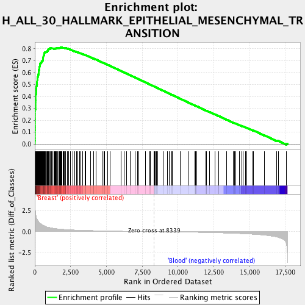

GSEA tests each collection of gene sets separately and reports the NES (nominal enrichment score) and p value of each gene set. FDR (false discovery rate) will also be calculated based on the p values within each collection.

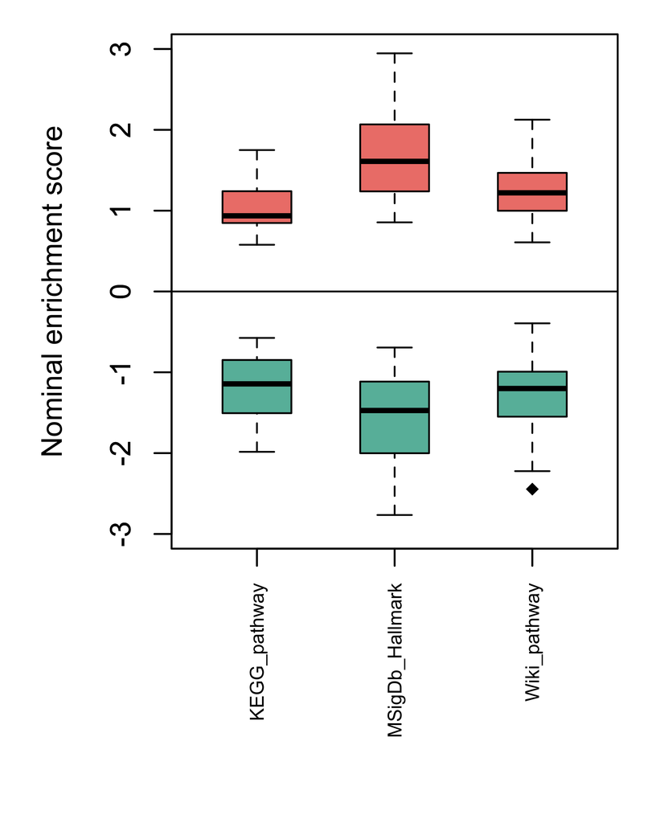

**Figure 2.** Distribution of nominal enrichment scores by gene set collections. Positive and negative scores are plotted separately.

## 2.2 Leading edge genes

There is often overlapping between gene sets in different collections, such as KEGG and Reactome pathways. As a result, top gene sets reported by GSEA might be redundant if they include the same leading edge genes with the highest levels of differential expression.

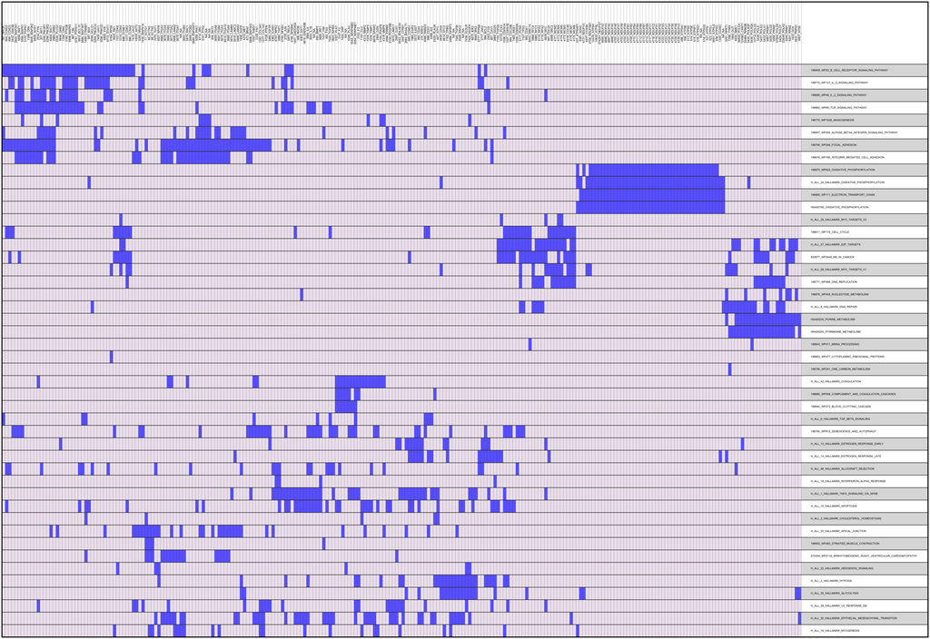

**Figure 3.** Leading edge analyis of top 46 gene sets and genes included by at least 4 of these gene sets. Colored blocks are genes included by the corresponding gene sets.

## 2.3 View and download results

**Download links:**

- All results in a zip file
- Results as Excel spreadsheets
- Results as R object
- Figures

**Table 1.** Summary of GSEA results. Gene sets were analyzed as collections. Click the links the view GSEA results of individual collections.

| Collection | Gene_Set | Blood > Breast | Breast > Blood |
| --- | --- | --- | --- |
| MSigDb_Hallmark | 50 | List | List |
| Wiki_pathway | 219 | List | List |
| KEGG_pathway | 82 | List | List |

**Table 2.** Top 50 gene sets with the lowest and highest nominal enrichment scores.

| Collection | Gene_set | Size | NES | PValue | FDR | Breast>Blood |
| --- | --- | --- | --- | --- | --- | --- |
| MSigDb_Hallmark | H_ALL_28_HALLMARK_MYC_TARGETS_V1 | 176 | -2.7651 | 0.0000 | 0.00000 | No |
| Wiki_pathway | 198843_WP411_MRNA_PROCESSING | 114 | -2.4449 | 0.0000 | 0.00000 | No |
| MSigDb_Hallmark | H_ALL_29_HALLMARK_MYC_TARGETS_V2 | 55 | -2.3299 | 0.0000 | 0.00000 | No |
| Wiki_pathway | 198860_WP111_ELECTRON_TRANSPORT_CHAIN | 81 | -2.2225 | 0.0000 | 0.00000 | No |
| MSigDb_Hallmark | H_ALL_27_HALLMARK_E2F_TARGETS | 193 | -2.1594 | 0.0000 | 0.00000 | No |
| Wiki_pathway | 198771_WP466_DNA_REPLICATION | 41 | -2.0923 | 0.0000 | 0.00000 | No |
| MSigDb_Hallmark | H_ALL_46_HALLMARK_ALLOGRAFT_REJECTION | 192 | -2.0838 | 0.0000 | 0.00000 | No |
| Wiki_pathway | 198853_WP477_CYTOPLASMIC_RIBOSOMAL_PROTEINS | 49 | -2.0583 | 0.0000 | 0.00000 | No |
| Wiki_pathway | 198870_WP623_OXIDATIVE_PHOSPHORYLATION | 51 | -2.0089 | 0.0000 | 0.00015 | No |
| MSigDb_Hallmark | H_ALL_34_HALLMARK_OXIDATIVE_PHOSPHORYLATION | 187 | -2.0009 | 0.0000 | 0.00021 | No |
| KEGG_pathway | HSA00190_OXIDATIVE_PHOSPHORYLATION | 110 | -1.9836 | 0.0000 | 0.00260 | No |
| Wiki_pathway | 198876_WP404_NUCLEOTIDE_METABOLISM | 17 | -1.8950 | 0.0000 | 0.00160 | No |
| MSigDb_Hallmark | H_ALL_18_HALLMARK_INTERFERON_ALPHA_RESPONSE | 94 | -1.8898 | 0.0000 | 0.00031 | No |
| Wiki_pathway | 198811_WP179_CELL_CYCLE | 98 | -1.8795 | 0.0000 | 0.00210 | No |
| Wiki_pathway | 198909_WP23_B_CELL_RECEPTOR_SIGNALING_PATHWAY | 155 | -1.8535 | 0.0000 | 0.00290 | No |
| Wiki_pathway | 920977_WP2446_RB_IN_CANCER | 85 | -1.8391 | 0.0000 | 0.00300 | No |
| Wiki_pathway | 198756_WP241_ONE_CARBON_METABOLISM | 25 | -1.8216 | 0.0000 | 0.00320 | No |
| KEGG_pathway | HSA00230_PURINE_METABOLISM | 163 | -1.8104 | 0.0000 | 0.02000 | No |
| KEGG_pathway | HSA00240_PYRIMIDINE_METABOLISM | 97 | -1.7818 | 0.0000 | 0.01900 | No |
| MSigDb_Hallmark | H_ALL_8_HALLMARK_DNA_REPAIR | 142 | -1.7488 | 0.0000 | 0.00140 | No |
| KEGG_pathway | HSA00970_AMINOACYL_TRNA_BIOSYNTHESIS | 43 | -1.7466 | 0.0039 | 0.02300 | No |
| Wiki_pathway | 198885_WP49_IL_2_SIGNALING_PATHWAY | 42 | -1.7175 | 0.0038 | 0.01500 | No |
| Wiki_pathway | 198770_WP127_IL_5_SIGNALING_PATHWAY | 68 | -1.7128 | 0.0019 | 0.01400 | No |
| Wiki_pathway | 198862_WP69_TCR_SIGNALING_PATHWAY | 87 | -1.6746 | 0.0000 | 0.02200 | No |
| Wiki_pathway | 198858_WP1602_NICOTINE_ACTIVITY_ON_DOPAMINERGIC_NEURONS | 21 | -1.6728 | 0.0039 | 0.02100 | No |
| MSigDb_Hallmark | H_ALL_22_HALLMARK_HEDGEHOG_SIGNALING | 34 | 1.7449 | 0.0083 | 0.00120 | Yes |
| Wiki_pathway | 198772_WP1539_ANGIOGENESIS | 23 | 1.7460 | 0.0043 | 0.02800 | Yes |
| KEGG_pathway | HSA00600_SPHINGOLIPID_METABOLISM | 42 | 1.7493 | 0.0020 | 0.12000 | Yes |
| Wiki_pathway | 198840_WP272_BLOOD_CLOTTING_CASCADE | 20 | 1.7744 | 0.0000 | 0.02300 | Yes |
| MSigDb_Hallmark | H_ALL_10_HALLMARK_APOPTOSIS | 156 | 1.7759 | 0.0000 | 0.00099 | Yes |
| Wiki_pathway | 198880_WP558_COMPLEMENT_AND_COAGULATION_CASCADES | 46 | 1.7987 | 0.0000 | 0.01800 | Yes |
| Wiki_pathway | 198816_WP185_INTEGRIN_MEDIATED_CELL_ADHESION | 95 | 1.8233 | 0.0000 | 0.01300 | Yes |
| Wiki_pathway | 198780_WP615_SENESCENCE_AND_AUTOPHAGY | 100 | 1.8402 | 0.0000 | 0.01200 | Yes |
| MSigDb_Hallmark | H_ALL_35_HALLMARK_GLYCOLYSIS | 193 | 1.8439 | 0.0000 | 0.00056 | Yes |
| Wiki_pathway | 672454_WP2118_ARRHYTHMOGENIC_RIGHT_VENTRICULAR_CARDIOMYOPATHY | 71 | 1.9415 | 0.0000 | 0.00330 | Yes |
| MSigDb_Hallmark | H_ALL_6_HALLMARK_TGF_BETA_SIGNALING | 53 | 1.9429 | 0.0000 | 0.00040 | Yes |
| Wiki_pathway | 198912_WP98_PROSTAGLANDIN_SYNTHESIS_AND_REGULATION | 28 | 1.9438 | 0.0039 | 0.00410 | Yes |
| MSigDb_Hallmark | H_ALL_14_HALLMARK_ESTROGEN_RESPONSE_LATE | 190 | 1.9934 | 0.0000 | 0.00029 | Yes |
| Wiki_pathway | 198795_WP306_FOCAL_ADHESION | 176 | 2.0026 | 0.0000 | 0.00170 | Yes |
| MSigDb_Hallmark | H_ALL_20_HALLMARK_APICAL_JUNCTION | 192 | 2.0189 | 0.0000 | 0.00019 | Yes |
| Wiki_pathway | 198903_WP383_STRIATED_MUSCLE_CONTRACTION | 38 | 2.0287 | 0.0000 | 0.00190 | Yes |
| MSigDb_Hallmark | H_ALL_3_HALLMARK_CHOLESTEROL_HOMEOSTASIS | 69 | 2.1147 | 0.0000 | 0.00000 | Yes |
| Wiki_pathway | 198807_WP244_ALPHA6_BETA4_INTEGRIN_SIGNALING_PATHWAY | 63 | 2.1251 | 0.0000 | 0.00000 | Yes |
| MSigDb_Hallmark | H_ALL_1_HALLMARK_TNFA_SIGNALING_VIA_NFKB | 195 | 2.1469 | 0.0000 | 0.00000 | Yes |
| MSigDb_Hallmark | H_ALL_13_HALLMARK_ESTROGEN_RESPONSE_EARLY | 193 | 2.1475 | 0.0000 | 0.00000 | Yes |
| MSigDb_Hallmark | H_ALL_42_HALLMARK_COAGULATION | 133 | 2.1976 | 0.0000 | 0.00000 | Yes |
| MSigDb_Hallmark | H_ALL_2_HALLMARK_HYPOXIA | 191 | 2.2608 | 0.0000 | 0.00000 | Yes |
| MSigDb_Hallmark | H_ALL_16_HALLMARK_MYOGENESIS | 193 | 2.3407 | 0.0000 | 0.00000 | Yes |
| MSigDb_Hallmark | H_ALL_39_HALLMARK_UV_RESPONSE_DN | 142 | 2.5509 | 0.0000 | 0.00000 | Yes |
| MSigDb_Hallmark | H_ALL_30_HALLMARK_EPITHELIAL_MESENCHYMAL_TRANSITION | 193 | 2.9458 | 0.0000 | 0.00000 | Yes |

*[Go to project home](http://zhezhangsh.github.io/RoCA)*

# 3 Appendix

Check out the **[RoCA home page](http://zhezhangsh.github.io/RoCA)** for more information.

## 3.1 References

- **R:** R Development Core Team, 2011. *R: A Language and Environment for Statistical Computing.* ISBN 3-900051-07-0. [Home page](http://www.R-project.org).
  - **Bioconductor:** Gentleman RC et al., 2004. *Bioconductor: open software development for computational biology and bioinformatics.* Genome Biology. [Home page](http://www.bioconductor.org).
  - **GSEA:** Subramanian A et al. 2005 *Gene set enrichment analysis: A knowledge-based approach for interpreting genome-wide expression profiles* PNAS. [Home page](http://software.broadinstitute.org/gsea/index.jsp)
  - **RoCA**
  - **Awsomics**

## 3.2 Reproduce this report

To reproduce this report:

1. Find the data analysis template you want to use and an example of its pairing YAML file [here](https://github.com/zhezhangsh/RoCA/wiki/Templates-and-examples) and download the YAML example to your working directory
2. To generate a new report using your own input data and parameter, edit the following items in the YAML file:
- *output* : where you want to put the output files
  - *home* : the URL if you have a home page for your project
  - *analyst* : your name
  - *description* : background information about your project, analysis, etc.
  - *input* : where are your input data, read instruction for preparing them
  - *parameter* : parameters for this analysis; read instruction about how to prepare input data
3. Run the code below within *R Console* or *RStudio*, preferablly with a new R session:

```r
if (!require(devtools)) { install.packages('devtools'); require(devtools); }
if (!require(RCurl)) { install.packages('RCurl'); require(RCurl); }
if (!require(RoCA)) { install_github('zhezhangsh/RoCAR'); require(RoCA); }

CreateReport(filename.yaml);  # filename.yaml is the YAML file you just downloaded and edited for your analysis
```

If there is no complaint, go to the *output* folder and open the *index.html* file to view report.

*[Go to project home](http://zhezhangsh.github.io/RoCA)*

*END OF DOCUMENT*